# Homework 2

Jakob Serlier

Assigned: 29 Oct 2019

## This homework is due by **18:00 on Wednesday, 6 November**. To complete this assignment, follow these steps:

1. Download the `homework2.Rmd` file from Canvas.
2. Open `homework2.Rmd` in RStudio.
3. Replace the “Your Name Here” text in the `author:` field with your own name.
4. Supply your solutions to the homework by editing `homework1.Rmd`.
5. When you have completed the homework and have **checked** that your code both runs in the Console and knits correctly when you click `Knit HTML`, rename the R Markdown file to `homework1_YourNameHere.Rmd`, and submit on Canvas. (YourNameHere should be changed to your own name.)

## Homework tips:

1. Instead of sending code line-by-line with `<ctrl-enter>`, you can send entire code chunks, and even run all of the code chunks in your .Rmd file. Look under the menu of the Source panel.
2. Run your code in the Console and Knit HTML frequently to check for errors.
3. You may find it easier to solve a problem by interacting only with the Console at first.

## Homework 1 outline

## Problem 1: Simple Boolean operations

> Tip: To check that your answer makes sense, you may want to try it out in the console with various choices of values for the variable `x`.

## (a) Checking equality.

Given a variable `x`, write a Boolean expression that evaluates to `TRUE` if the variable `x` is equal to `94842` (the numeric value).

```r
x <- 94842 #assigning the 94842 int value to x
# Insert your Boolean expression here
x == 94842 #bool eval for x
```

```
## [1] TRUE
```

## (b) Checking inequality.

Given a variable `x`, write a Boolean expression that evaluates to `TRUE` if the variable `x` is *not* `NA` (i.e., is not missing).

```r
x <- NA #assignment
# Insert your Boolean expression here
!is.na(x) #bool check
```

```
## [1] FALSE
```

## (c) Checking if a number is in a given range.

Given a (possibly negative) number `x`, write a Boolean expression that returns `TRUE` if and only if `x` is smaller than `-12` or bigger than `29`.

```r
x <- -13
# Insert your Boolean expression here
x < -12 | x > 29
```

```
## [1] TRUE
```

## Problem 2: Vector Boolean operations

## (a) R has two kinds of Boolean operators implemented, single (`&`, `|`) and double (`&&`, `||`).

One of these operators takes advantage of something called *lazy evaluation* while the other does not. They also don’t behave the same way when applied to *vectors*.

Read the help file (`help("||")`) and construct some examples to help figure out how the two behave.

To help you get started, try out the following two examples in your console:

```r
# Example:  The variable y.prob2a is not defined.
# (Do not define it!)
# What happens when you run this code?
x.prob2a <- 5
(x.prob2a < 10) | (y.prob2a > 2)
(x.prob2a < 10) || (y.prob2a > 2)
```

```r
# Define vectors
x.prob2a.vec <- c(TRUE, FALSE, FALSE)
y.prob2a.vec <- c(TRUE, TRUE, FALSE)

# Apply various Boolean operations to see what happens
x.prob2a.vec & y.prob2a.vec
```

```
## [1]  TRUE FALSE FALSE
```

```r
x.prob2a.vec && y.prob2a.vec
```

```
## [1] TRUE
```

```r
x.prob2a.vec | y.prob2a.vec
```

```
## [1]  TRUE  TRUE FALSE
```

```r
x.prob2a.vec || y.prob2a.vec
```

```
## [1] TRUE
```

Can you explain what’s happening? Write up a brief explanation below.

&&, &, |, and || are all logic operators in R. || and && are element based logic operators, whereas | and & can be used as vector based logic operators. (vector | (or &) vector) evaluates each element in the vector, and gives that as a logical output. (vector || (or &&) vector) evaluates the *first* element in each vector for the returned boolean output.

In the first example, as y.prob2a is not defined/instantiated, you cannot perform a vector-wise operation such as | or &. It cannot compare elements of a vector to elements of an undefined vector.Therefore it cannot return a vector with booleans, and throws an exception.

For the || example, the ‘or’ statement returns true if either of the statements are true. Since the first vector is defined and the first element holds true, the logic operaton returns true without the second vector having to be defined.

## (b) Using `all()`

Two people were asked to give their preferences between two options: [Facebook, Twitter], [Firefox, Chrome], [Mac, PC], [Summer, Winter]. Their results are given below.

```r
alice.prefs <- c("Twitter", "Chrome", "Mac", "Summer")
bob.prefs <- c("Facebook", "Chrome", "PC", "Summer")
```

Use the `all()` function to determine if the two people have identical preferences. (Your code should ouput a single Boolean value, either `TRUE` or `FALSE`)

```r
# Edit me
all(c(alice.prefs == bob.prefs))
```

```
## [1] FALSE
```

## (c) Using `any()`

Use the `any()` function to determine if the two people have any preferences in common. (Your code should output a single Boolean value, either `TRUE` or `FALSE`)

```r
# Edit me
any(c(alice.prefs == bob.prefs))
```

```
## [1] TRUE
```

## (d) Missing values.

Let `age` be the vector defined below.

```r
age <- c(18, NA, 25, 71, NA, 45, NA, NA, 18)
```

Write a Boolean expression that checks whether each entry of `age` is missing (recall missing values are denoted by `NA`). Your expression should return a Boolean vector having the same length as `age`.

```r
#question for the instructor, I tried the following code but it didnt work. Why did it not work? The isNA vector returns a vector with NA. Can't I use logic operators for checking NA values to regular values?
age_NA <- rep(NA, length(age))
is_NA <- (age == age_NA)


# Edit me -> my answer.
bool_vec <-is.na(age)
length(bool_vec) == length(age) #lengths are the same
```

```
## [1] TRUE
```

## Problem 3: Referencing vector elements

## (a) `which()` practice

Write code that returns the indexes of `age` that are missing.

```r
# Edit me
which(is.na(age))
```

```
## [1] 2 5 7 8
```

## (b) Getting non-missing values

Write code that uses negative indexes and your solution from (a) to return only the values of `age` that are *not* missing. (i.e., your code should result in a vector with elements: 18, 25, 71, 45, 18)

```r
# question: is it best practise to only use lowercase letters in declaration of variables? ex. should I use non_na_age or non_NA_age, or does it not matter?
# Edit me

(non_NA_age <- age[-which(is.na(age))]) #seems more complicated than just using the ! operator.
```

```
## [1] 18 25 71 45 18
```

## (c) A more direct way of getting non-missing values

Using the negation operator `!` and the `is.na()` function, write an expression that returns only the values of `age` that are *not* missing.

```r
# Edit me
#oops, I already used the ! operator in the previous answer..
(non_NA_age <- age[which(!is.na(age))])
```

```
## [1] 18 25 71 45 18
```

## (d) More `which()` practice

For the next three problems we will go back to the `cars` data set.

```r
speed <- cars$speed
dist <- cars$dist
```

Write code to figure out which cars had a stopping distance of 15 feet or more.

```r
# Edit me
cars[cars$dist > 15, ]
```

```
##    speed dist
## 4      7   22
## 5      8   16
## 7     10   18
## 8     10   26
## 9     10   34
## 10    11   17
## 11    11   28
## 13    12   20
## 14    12   24
## 15    12   28
## 16    13   26
## 17    13   34
## 18    13   34
## 19    13   46
```

[output cut: 31 more lines]

```r
#or ... cars[which(dist > 15), ]
```

## (e) `which.min`, `which.max` practice

Use the `which.min()` function to figure out which car had the *shortest* stopping distance. (Your code should return the car’s index.)

```r
# Edit me
which.min(cars$dist) #returns the index, to retrieve the row do cars[index, ]
```

```
## [1] 1
```

## (f) More practice

Use the `which.max()` function to figure out the *speed* of the car that had the *longest* stopping distance. (Your code should return the car’s speed.)

```r
# Edit me
cars[which.max(cars$dist), 'speed']
```

```
## [1] 24
```

## Problem 4: Data frame basics

## (a) Importing data.

In Lecture 2 we saw how to use the `read.table()` function to import the survey data. Now we’ll use a different function. Use the `read.csv()` function to import the survey data into a variable called `survey`.

```r
# Edit me
#Using relative path to my git folder
survey <- read.csv(file="./datasets/survey.csv", header=TRUE, sep=",")
```

**Tip**: The data file is available on Canvas. You may download the file to a directory on your machine then import it.

## (b) `$` notation

Use the `$` operator to select the TVhours column from the `survey` data

```r
# Edit me
(s_tvhours <- survey$TVhours)
```

```
##  [1]  2 15 16  0  2  5  0  4  0  0 14  6 10 15  4  4 10  7 33  8  8  3  0
## [24]  0  0  0  6  1  0  0  4
```

## (c) [,] notation

Repeat part (b) using `[,]` notation. i.e., Use `[,]` notation to select the TVhours column from the `survey` data by name (i.e., obtain this column by using the name “TVhours” instead of using the column number)

```r
# Edit me
(s_tvhours <- survey[, 'TVhours'])
```

```
##  [1]  2 15 16  0  2  5  0  4  0  0 14  6 10 15  4  4 10  7 33  8  8  3  0
## [24]  0  0  0  6  1  0  0  4
```

## (d) [[]] notation

Repeat part (c) with [[]] notation.

```r
# Edit me
(s_tvhours <- survey[['TVhours']])
```

```
##  [1]  2 15 16  0  2  5  0  4  0  0 14  6 10 15  4  4 10  7 33  8  8  3  0
## [24]  0  0  0  6  1  0  0  4
```

## (e) [] notation

Repeat part (d), but this time using single blackets (`[ ]`) notation.

(Observe that this returns a new single-column *data frame*, not just a vector.)

```r
# Edit me
(s_tvhours <- survey['TVhours'])
```

```
##    TVhours
## 1        2
## 2       15
## 3       16
## 4        0
## 5        2
## 6        5
## 7        0
## 8        4
## 9        0
## 10       0
## 11      14
## 12       6
## 13      10
## 14      15
```

[output cut: 17 more lines]

## (f) `subset()` practice

Use the `subset()` function to select all the survey data on Program and OperatingSystem for respondents whose Rexperience is “Never used” *or* who watched 5 or more hours of TV last week.

```r
# Edit me
(subset(survey, Rexperience == 'Never used' | TVhours > 5))
```

```
##    ï..X Program                PriorExp          Rexperience
## 1     1     PPM         Some experience           Never used
## 2     2     PPM Never programmed before           Never used
## 3     3     PPM         Some experience     Basic competence
## 5     5     PPM Never programmed before           Never used
## 6     6     PPM Never programmed before           Never used
## 10   10   Other Never programmed before           Never used
## 11   11    MISM         Some experience     Basic competence
## 12   12     PPM         Some experience Installed on machine
## 13   13    MISM    Extensive experience     Basic competence
## 14   14   Other         Some experience           Never used
## 17   17     PPM         Some experience     Basic competence
## 18   18     PPM         Some experience Installed on machine
## 19   19     PPM         Some experience Installed on machine
## 20   20   Other         Some experience           Never used
```

[output cut: 23 more lines]

## Problem 5: Data summaries and inline code practice.

## (a) Bar graph

Create a bar graph of respondents’ Rexperience.

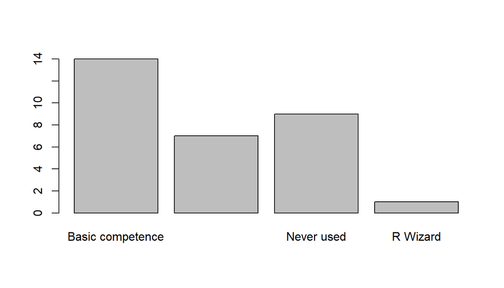

```r
# Edit me
plot(survey$Rexperience)
```